# usAirData Package

Alexis Nguyen

2025-11-30

## R Markdown

```r
# load my package while I am working on it
devtools::load_all()
```

## About This Package

This package uses a US airline cost dataset and it includes three functions I added that: - Calculates the average cost - Finds the row with the highest cost - Shows a plot that shows cost over time I chose this dataset becaise it was easy for me to work with and I also enjoy the topic because it is related to travel and airlines. This made it more interesting. This ptoject helped me learn more about R and how creating a package goes, and how to add my own details and pizzazz.

## Loading the Dataset

```r
data(airdata)
head(airdata)
```

```
##   rownames firm year   output    cost  price     load
## 1        1    1 1970 0.952757 1140640 106650 0.534487
## 2        2    1 1971 0.986757 1215690 110307 0.532328
## 3        3    1 1972 1.091980 1309570 110574 0.547736
## 4        4    1 1973 1.175780 1511530 121974 0.540846
## 5        5    1 1974 1.160170 1676730 196606 0.591167
## 6        6    1 1975 1.173760 1823740 265609 0.575417
```

This shows the first few rows of the dataset which can make sure it loads in.

## Average Cost Function

```r
avg_cost(airdata)
```

```
## [1] 1122524
```

This functions calculates the average cost to the entire dataset.

## Highest Cost Row

```r
highest_cost(airdata)
```

```
##    rownames firm year  output    cost  price     load
## 15       15    1 1984 1.93646 4748320 823411 0.625603
```

This function finds the row with the highest cost value.

## Plot of Cost Over Time

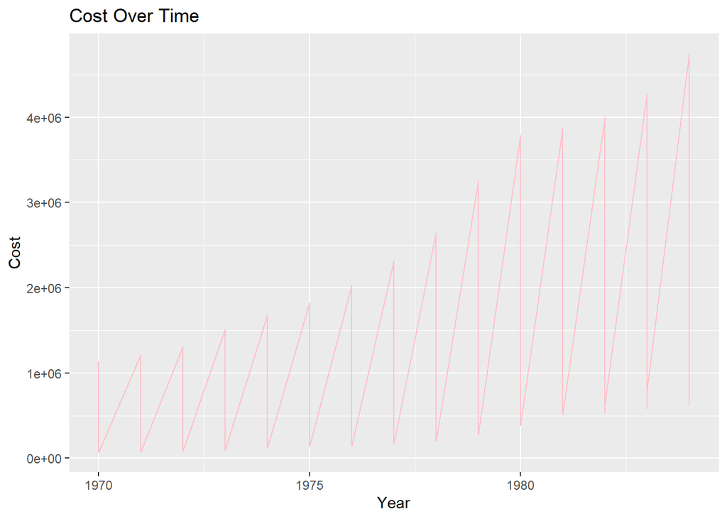

```r
plot_cost_over_time(airdata)
```

This function makes a line plot that shows how cost changes over the years.

## Reflection

This project helped me learn how to build a simple R package while adding my own elements to it.During this project I got to implement something I find interesting and enjoyable so it made the project go by faster. It was somewhat confusing at first, but everything came together at the end.